# Project Milestone 6

Authors: Kathy Nazarian, Kimberly Michel

## Visualizations

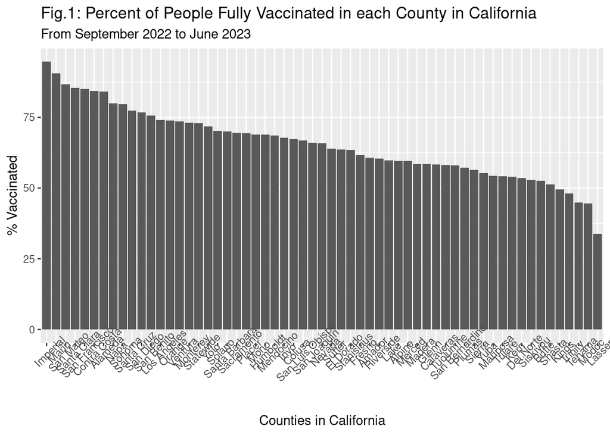

```
## # A tibble: 57 × 5
## # Groups:   county [57]
##    county          Q1    Q2    Q3    Q4
##    <chr>        <dbl> <dbl> <dbl> <dbl>
##  1 Alameda      0.254  2.49  1.75     0
##  2 Alpine       0.152  2.52  1.77     0
##  3 Amador       0.255  2.42  1.76     0
##  4 Butte        0.242  2.51  1.72     0
##  5 Calaveras    0.252  2.46  1.75     0
##  6 Colusa       0.248  2.53  1.68     0
##  7 Contra Costa 0.246  2.48  1.75     0
##  8 Del Norte    0.243  2.55  1.67     0
##  9 El Dorado    0.244  2.40  1.88     0
## 10 Fresno       0.251  2.50  1.72     0
## # ℹ 47 more rows
```

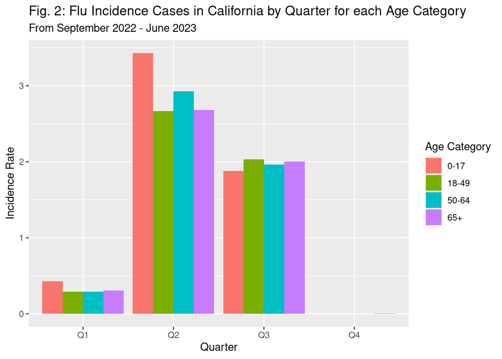

## Problem Statement

We wanted to identify whether there were any discrepancies or disparities among flu infections in California between September 2022 - June 2023. Comparing flu infections rates and vaccination rates by age allowed us the opportunity to identify these gaps. Showcasing the data by different age categories allows us to understand which groups are affected most by severe or new infections based on vaccination rates. This could allow us to further our research in implementing different policies to close the gaps.

## Methods

Source: Datasets appear to be from health departments within CA and Los Angeles. The data that was collected includes cases of flu as well as vaccine uptake data. Timeframe of each dataset ranges between September 2022 - June 2023 within different counties across California.

Description of cleaning and creating new variables:

- We renamed all data set column names to be in snake case and have similar names to each other to facilitate merging the data sets later.
- New columns with formulas were created to calculate COVID vaccination rates and flu incidence rates for the respective data frame. In order to achieve this, we had to reformat several values from chr to num.
- We cleaned data by removing columns in each data frame that we no longer needed. This included removing demographics that we did not use for analysis, including race/ethnicity and gender. We also excluded columns that would not be used for calculations, like the number of people who were unvaccinated or the number of new severe flu infections.
- We created new datasets by merging several together. Los Angeles was initially excluded from the data set that included all other counties in California, so we were able to add it to that data set by making Los Angeles its own column. We then merged the COVID vaccination data set and the flu incidence data set to be able to analyze the relationship using one data frame.
- The date category was adjusted to be by quarter. Quarters (Q1-4) were split up into 4 increments based on timeline in raw data. For reference:
  - Q1 = Sep - Nov ’22
  - Q2 = Dec ’22 - Feb ’23
  - Q3 = March - May ’23
  - Q4 = June ’23

Analytic methods: Retrospective data analysis to identify vaccination and flu incidence rates among California residents among September 2022 - June 2023.

## Results + Discussion

Figure 1 demonstrates the average COVID-19 vaccination rates of all counties in California, only including those that are fully vaccinated. The graph shows that Imperial County (94.6%) and Lassen County (33.7%) have the highest and lowest vaccination rates among all counties. Figure 2 display that Quarter 2 (Dec ’22 - Feb ’23), had the highest flu incidence rates among all age groups, following Q3 (March - May ’23), and Q1 (Sep - Nov ’22), respectively. Q4 (June ’23) had no data.